# Avaliação 02 - Estatística e Informática - TP1

### INFORMAÇÕES E RECOMENDAÇÕES:

- A avaliação é **INDIVIDUAL**.
- Clique sobre o **SEU NOME** e faça o download do arquivo que contém a **SUA PROVA**.
- Leia atentamente todas as questões, pois a interpretação faz parte da avaliação.
- Apresente **TODOS** os resultados com, no mínimo, $04$ casas decimais, no campo de resposta na própria avaliação.
- Poderá ser utilizado o **R**, o **Excel** ou a **calculadora científica**, contudo, **NÃO SERÁ NECESSÁRIO ENVIAR OS CÓDIGOS OU CÁLCULOS**, somente a **própria avaliação** com as respostas nos respectivos campos.
- A Prova deverá ser entregue até as **23:59h** do dia **11/08/2022** via Google Classroom, Atividade: **“AVALIAÇÃO 02”**.
- A prova poderá ser impressa, preenchida e as fotos poderão ser anexadas e enviadas.
- Poderá ser utilizada a ferramenta de **preencher e assinar** do *Adobe Acrobat Reader* . Ao final desta página será apresentado um breve tutorial de como utilizar essa ferramenta.

### Arquivos para download:

| Nome |
| --- |
| [Alan Gabriel de Souza](https://github.com/arpanosso/estatinfo/raw/master/docs/p12/p2/TP1/01.pdf) |
| [Alan Moretto Ferreira de Aguiar](https://github.com/arpanosso/estatinfo/raw/master/docs/p12/p2/TP1/02.pdf) |
| [Alessandra da Silva Andrade](https://github.com/arpanosso/estatinfo/raw/master/docs/p12/p2/TP1/03.pdf) |
| [Amanda Caroline Bertuso](https://github.com/arpanosso/estatinfo/raw/master/docs/p12/p2/TP1/04.pdf) |
| [Augusto Rosario Vieira](https://github.com/arpanosso/estatinfo/raw/master/docs/p12/p2/TP1/05.pdf) |
| [Beatriz dos Reis Jesus Silva](https://github.com/arpanosso/estatinfo/raw/master/docs/p12/p2/TP1/06.pdf) |
| [Bruno Borges Manginelli](https://github.com/arpanosso/estatinfo/raw/master/docs/p12/p2/TP1/07.pdf) |
| [Eduardo Venturinelli](https://github.com/arpanosso/estatinfo/raw/master/docs/p12/p2/TP1/08.pdf) |
| [Enzo Morillo](https://github.com/arpanosso/estatinfo/raw/master/docs/p12/p2/TP1/09.pdf) |
| [Felipe Machado Camargo](https://github.com/arpanosso/estatinfo/raw/master/docs/p12/p2/TP1/10.pdf) |
| [Fernando Junqueira de Almeida Galletti](https://github.com/arpanosso/estatinfo/raw/master/docs/p12/p2/TP1/11.pdf) |
| [Filipe Coelho de Oliveira](https://github.com/arpanosso/estatinfo/raw/master/docs/p12/p2/TP1/12.pdf) |
| [Francisco Eduardo Boissoni Ogata](https://github.com/arpanosso/estatinfo/raw/master/docs/p12/p2/TP1/13.pdf) |
| [Gabriel Henrique da Silva Crispim](https://github.com/arpanosso/estatinfo/raw/master/docs/p12/p2/TP1/14.pdf) |
| [Gabriel Queiroz](https://github.com/arpanosso/estatinfo/raw/master/docs/p12/p2/TP1/15.pdf) |
| [Geysor Taylon Lima Vieira](https://github.com/arpanosso/estatinfo/raw/master/docs/p12/p2/TP1/16.pdf) |
| [Guilherme Ligabue Pereira](https://github.com/arpanosso/estatinfo/raw/master/docs/p12/p2/TP1/17.pdf) |
| [Guilherme Pinto Ferreira de Oliveira](https://github.com/arpanosso/estatinfo/raw/master/docs/p12/p2/TP1/18.pdf) |
| [Guilherme Santos de Moura](https://github.com/arpanosso/estatinfo/raw/master/docs/p12/p2/TP1/19.pdf) |
| [Guilherme Teixera Padilha Stefano](https://github.com/arpanosso/estatinfo/raw/master/docs/p12/p2/TP1/20.pdf) |
| [Helora Machado Sampaio da Silva](https://github.com/arpanosso/estatinfo/raw/master/docs/p12/p2/TP1/21.pdf) |
| [Josiel Marcos Carvalho Soares](https://github.com/arpanosso/estatinfo/raw/master/docs/p12/p2/TP1/22.pdf) |
| [Kailaine do Nascimento Ferreira](https://github.com/arpanosso/estatinfo/raw/master/docs/p12/p2/TP1/23.pdf) |
| [Lorenzo Pagnano Bocchi](https://github.com/arpanosso/estatinfo/raw/master/docs/p12/p2/TP1/24.pdf) |
| [Luccas Casella Mattiello](https://github.com/arpanosso/estatinfo/raw/master/docs/p12/p2/TP1/25.pdf) |
| [Luis Otavio Osorio Rosa](https://github.com/arpanosso/estatinfo/raw/master/docs/p12/p2/TP1/26.pdf) |
| [Luiz Antônio Bonaldo Citrangulo](https://github.com/arpanosso/estatinfo/raw/master/docs/p12/p2/TP1/27.pdf) |
| [Luiz Fernando de Mello](https://github.com/arpanosso/estatinfo/raw/master/docs/p12/p2/TP1/28.pdf) |
| [Murilo Augusto Destefani](https://github.com/arpanosso/estatinfo/raw/master/docs/p12/p2/TP1/29.pdf) |
| [Pedro Costa Scrivanti](https://github.com/arpanosso/estatinfo/raw/master/docs/p12/p2/TP1/30.pdf) |
| [Pedro Henrique Batista dos Santos](https://github.com/arpanosso/estatinfo/raw/master/docs/p12/p2/TP1/31.pdf) |
| [Pedro Lucas de Carvalho Galina](https://github.com/arpanosso/estatinfo/raw/master/docs/p12/p2/TP1/32.pdf) |
| [Pietro Tambasco Talhari](https://github.com/arpanosso/estatinfo/raw/master/docs/p12/p2/TP1/33.pdf) |
| [Rafael Barboza Fredi](https://github.com/arpanosso/estatinfo/raw/master/docs/p12/p2/TP1/34.pdf) |
| [Rafael Cavichioli Lopes](https://github.com/arpanosso/estatinfo/raw/master/docs/p12/p2/TP1/35.pdf) |
| [Rafael Henrique de Souza Silva](https://github.com/arpanosso/estatinfo/raw/master/docs/p12/p2/TP1/36.pdf) |
| [Rian Nogueira](https://github.com/arpanosso/estatinfo/raw/master/docs/p12/p2/TP1/37.pdf) |
| [Sarah Donadeli Pagliarone](https://github.com/arpanosso/estatinfo/raw/master/docs/p12/p2/TP1/38.pdf) |
| [Taina Oliveira Alves](https://github.com/arpanosso/estatinfo/raw/master/docs/p12/p2/TP1/39.pdf) |
| [Theo Safatle Telles](https://github.com/arpanosso/estatinfo/raw/master/docs/p12/p2/TP1/40.pdf) |
| [Thiago Lorenzo Girardi](https://github.com/arpanosso/estatinfo/raw/master/docs/p12/p2/TP1/41.pdf) |
| [Yara de Assis Serafim](https://github.com/arpanosso/estatinfo/raw/master/docs/p12/p2/TP1/42.pdf) |

### Tutorial para Preenchimento da Avaliação.

#### 01) Faça o download da sua prova e salve em uma pasta no seu computador.

Após esse procedimento, clique duas vezes sobre o arquivo. Abra-o utilizando a Adob Acrobat Reader (o download do programa pode ser feito no link-https://get.adobe.com/br/reader/).

[figure not shown]

#### 2) O arquivo da sua prova será aberto no programa, como apresentado abaixo:

[figure not shown]

#### 3) Ative a ferramenta **Preencher e assinar** do Adobe.

Para isso clique no menu **Assinar** e em seguida clique na opção **Preencher e assinar**:

[figure not shown]

#### 4) Observe que será apresentada a barra *Preencher e assinar* com várias fermentas.

[figure not shown]

Clique na ferramenta **Adicionar Texto**, como apresentado na figura abaixo:

[figure not shown]

#### 5) Preencha os campos com as suas respostas:

Em seguida, posicione o cursos sobre o campo que deseja preencher e digite a resposta.

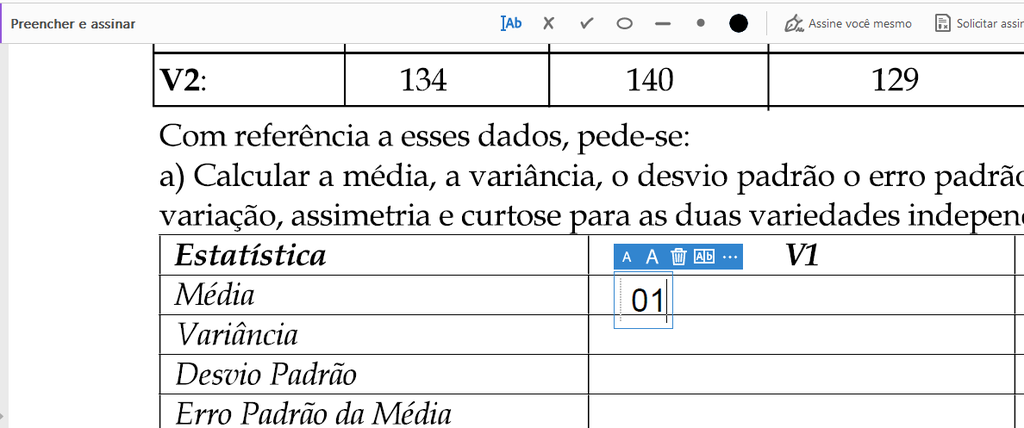

Repita esse procedimento para todos os campos da prova.

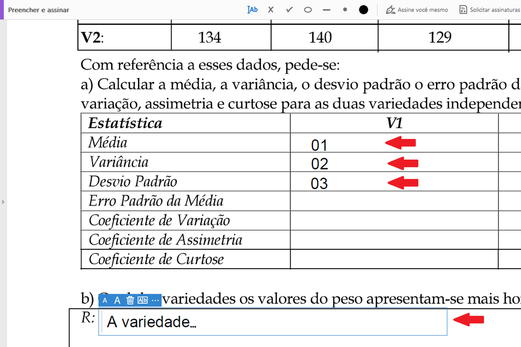

#### 6) Salve a prova preenchida:

Para realizar essa etapa, clique no menu **Arquivo**:

[figure not shown]

Em seguida selecione **Salvar como…**

[figure not shown]

Escolha a pasta onde o arquivo com a prova preenchida será salvo:

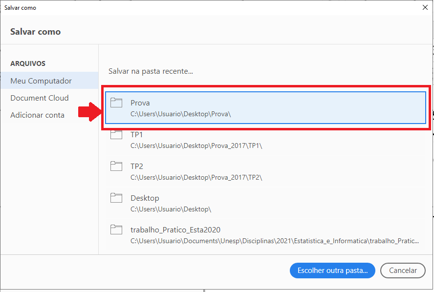

No exemplo, selecionamos a mesma pasta de origem da prova, e clique em **Salvar**:

[figure not shown]

Se necessário substitua o arquivo ou simplesmente salve a prova preenchida com outro nome.

[figure not shown]

Pronto, agora você pode enviar a sua prova no **Google Classroom**.